# HW6_Sonam

sonam.rathod@rutgers.edu

2024-11-16

#### Find an independent variable to predict your time-series (2 points)

**Dependent variable** - the number of baggage complaints (Baggage)

**Independent variables** - Scheduled, Cancelled, and Enplaned

```r
library(forecast)
```

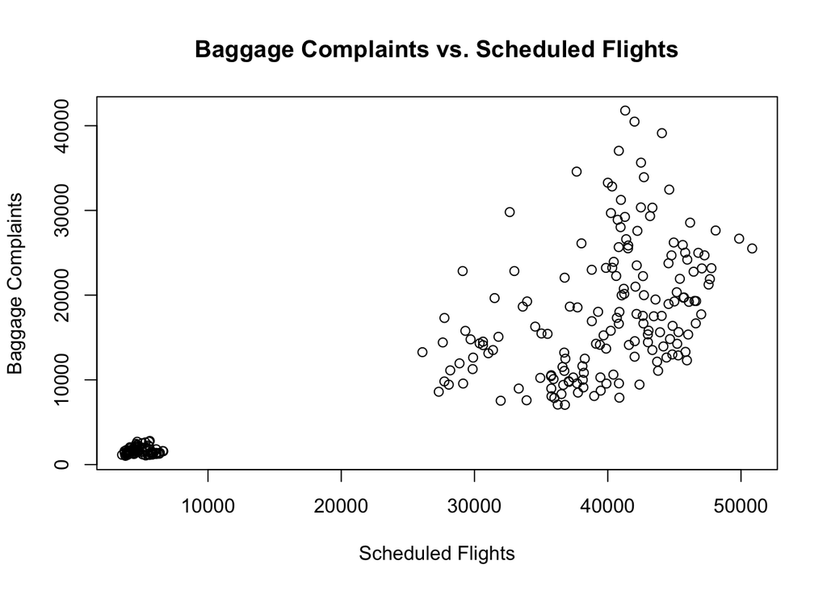

```r
library(ggplot2)

baggagecomplaints <- read.csv("~/Downloads/baggagecomplaints.csv")
plot(baggagecomplaints$Scheduled, baggagecomplaints$Baggage,
     xlab = "Scheduled Flights",
     ylab = "Baggage Complaints",
     main = "Baggage Complaints vs. Scheduled Flights")
```

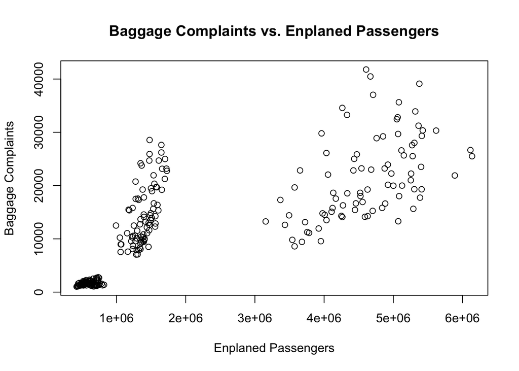

```r
plot(baggagecomplaints$Enplaned, baggagecomplaints$Baggage,
     xlab = "Enplaned Passengers",
     ylab = "Baggage Complaints",
     main = "Baggage Complaints vs. Enplaned Passengers")
```

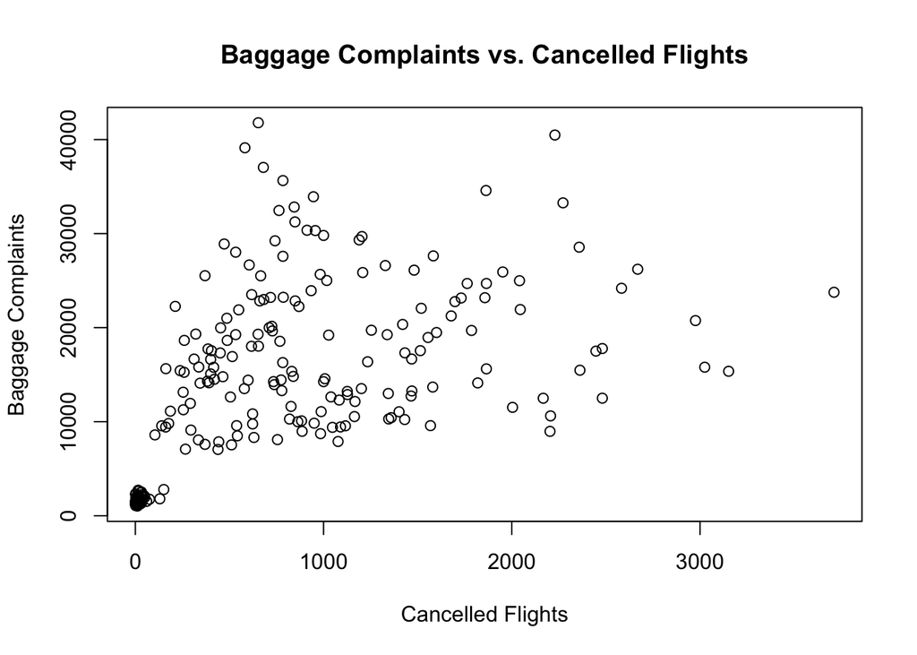

```r
# Plot Baggage vs. Cancelled
plot(baggagecomplaints$Cancelled, baggagecomplaints$Baggage,
     xlab = "Cancelled Flights",
     ylab = "Baggage Complaints",
     main = "Baggage Complaints vs. Cancelled Flights")
```

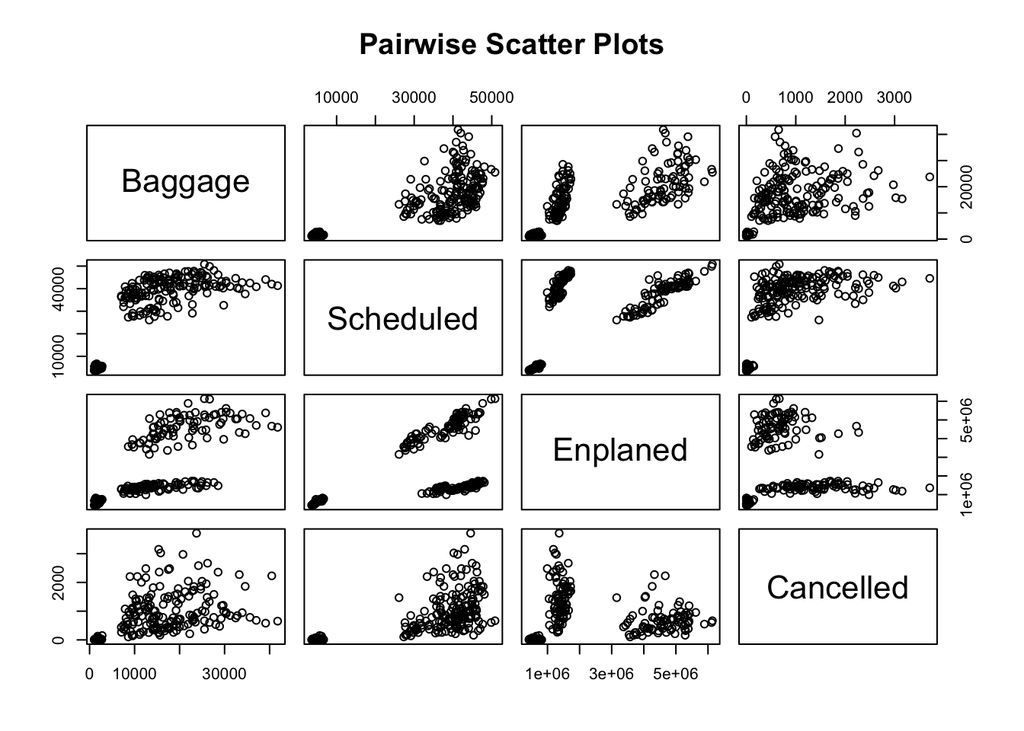

```r
pairs(~ Baggage + Scheduled + Enplaned + Cancelled, data = baggagecomplaints,
      main = "Pairwise Scatter Plots")
```

```r
numeric_data <- baggagecomplaints[, !(names(baggagecomplaints) %in% c("Month", "Year", "Airline"))]

numeric_data <- numeric_data[, sapply(numeric_data, is.numeric)]
cor(numeric_data)
```

```
##             Baggage Scheduled Cancelled  Enplaned
## Baggage   1.0000000 0.8174484 0.5944247 0.7673189
## Scheduled 0.8174484 1.0000000 0.7006648 0.6067396
## Cancelled 0.5944247 0.7006648 1.0000000 0.1238678
## Enplaned  0.7673189 0.6067396 0.1238678 1.0000000
```

##### Based on correlation matrix, Baggage complaints has highest correlation with Schedule (0.81744), hence, selecting Scheduled as the independent variable for predicting baggage complaints.

#### Perform regression (2 Points)

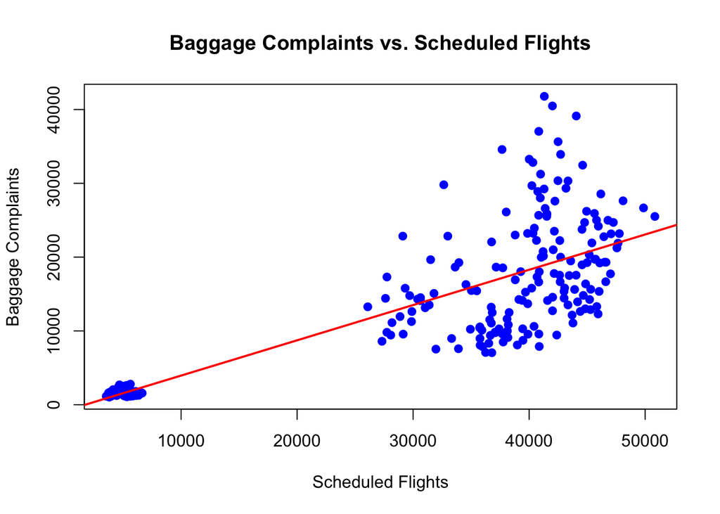

```r
mfit <- lm(Baggage ~ Scheduled, data = baggagecomplaints)
plot(baggagecomplaints$Scheduled, baggagecomplaints$Baggage, col = "blue", pch=19,
     main = "Baggage Complaints vs. Scheduled Flights",
     xlab = "Scheduled Flights", ylab = "Baggage Complaints")
abline(mfit, col = "red", lwd = 2)
```

#### Perform Model Acceptance Steps and show the interpretation of the model output (3 Points)

```r
summary(mfit)
```

```
##
## Call:
## lm(formula = Baggage ~ Scheduled, data = baggagecomplaints)
##
## Residuals:
##      Min       1Q   Median       3Q      Max
## -10808.9  -3512.8     91.9   1209.7  22873.3
##
## Coefficients:
##              Estimate Std. Error t value Pr(>|t|)
## (Intercept) -830.0252   700.6720  -1.185    0.237
## Scheduled      0.4779     0.0213  22.439   <2e-16 ***
## ---
## Signif. codes:  0 '***' 0.001 '**' 0.01 '*' 0.05 '.' 0.1 ' ' 1
##
## Residual standard error: 5768 on 250 degrees of freedom
## Multiple R-squared:  0.6682, Adjusted R-squared:  0.6669
## F-statistic: 503.5 on 1 and 250 DF,  p-value: < 2.2e-16
```

When there are zero scheduled flights, the predicted number of baggage complaints is -830.02, which is practically not possible. For every additional scheduled flight, the number of baggage complaints is predicted to increase by 0.4779 on average. The coefficient is highly significant with p-value. Multiple R-squared: 0.6682, Adjusted R-squared: 0.6669 66.8% of the variance in Baggage is explained by Scheduled.

F-statistic = 503.5, p-value < 2.2e-16: The model is highly significant. This confirms that the Scheduled flight has a significant impact on the Baggage Complaints.

#### Perform Residual Analysis and explain the insights (3 Points)

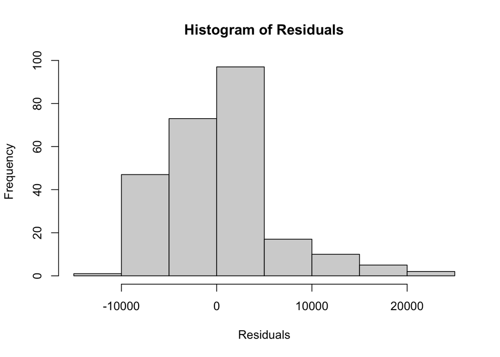

```r
res <- residuals(mfit)
hist(res, main = "Histogram of Residuals", xlab = "Residuals")
```

The histogram shows that the residuals are asymmetric, there appears to be some skewness.

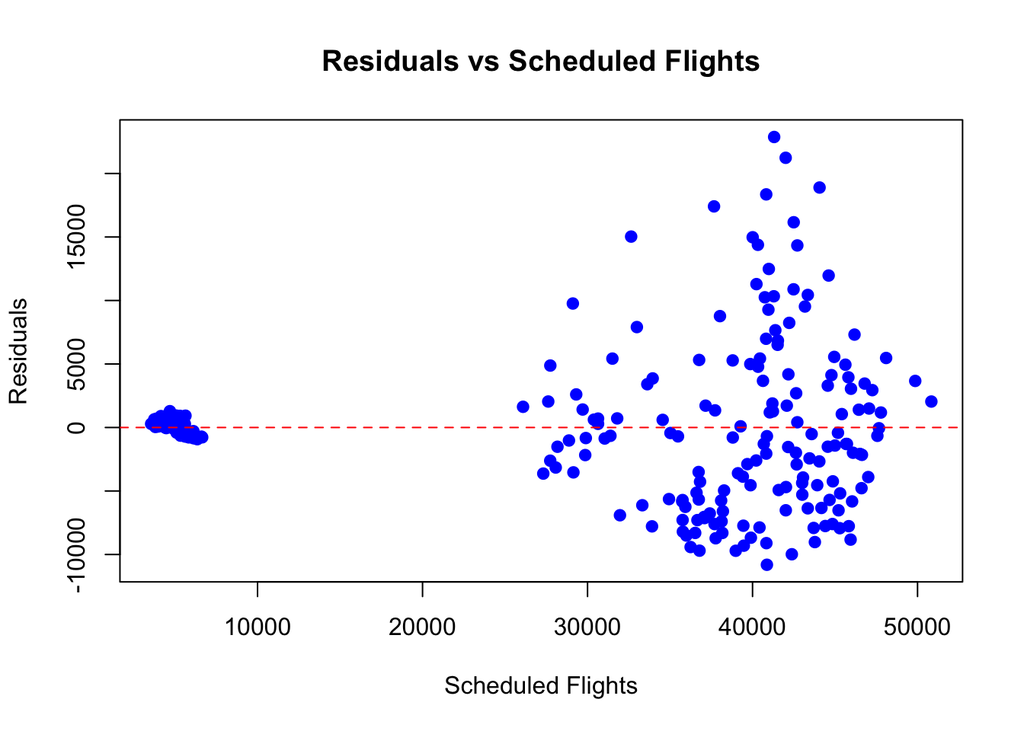

```r
plot(res ~ baggagecomplaints$Scheduled,
     xlab = "Scheduled Flights", ylab = "Residuals",
     main = "Residuals vs Scheduled Flights", pch = 19, col = "blue")
abline(h = 0, col = "red", lty = 2)
```

```r
library(forecast)
forecast_val <- forecast(mfit, newdata = data.frame(Scheduled = 50000))
print(forecast_val)
```

```
##   Point Forecast    Lo 80    Hi 80    Lo 95    Hi 95
## 1       23067.03 15617.11 30516.96 11648.19 34485.88
```

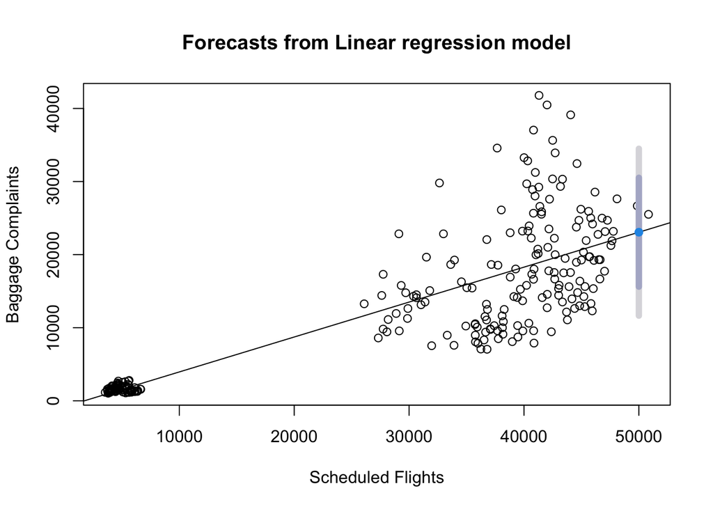

```r
plot(forecast_val, xlab = "Scheduled Flights", ylab = "Baggage Complaints")
```

```r
confint(mfit, level = 0.95)
```

```
##                    2.5 %      97.5 %
## (Intercept) -2209.997604 549.9472009
## Scheduled       0.435992   0.5198904
```

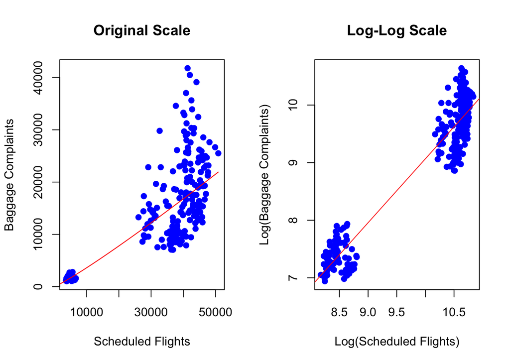

```r
par(mfrow = c(1, 2)) # Split plot area
fit_log <- lm(log(baggagecomplaints$Baggage) ~ log(baggagecomplaints$Scheduled), data = baggagecomplaints)

# Plot 1: Original Scale
plot(Baggage ~ Scheduled, data = baggagecomplaints,
     xlab = "Scheduled Flights", ylab = "Baggage Complaints",
     main = "Original Scale",
     pch = 19, col = "blue")
lines(1:max(baggagecomplaints$Scheduled), exp(fit_log$coef[1] + fit_log$coef[2] * log(1:max(baggagecomplaints$Scheduled))), col = "red")

# Plot 2: Log-Log Scale
plot(log(baggagecomplaints$Baggage) ~ log(baggagecomplaints$Scheduled), data = baggagecomplaints,
     xlab = "Log(Scheduled Flights)", ylab = "Log(Baggage Complaints)",
     main = "Log-Log Scale",
     pch = 19, col = "blue")
abline(fit_log, col = "red")
```

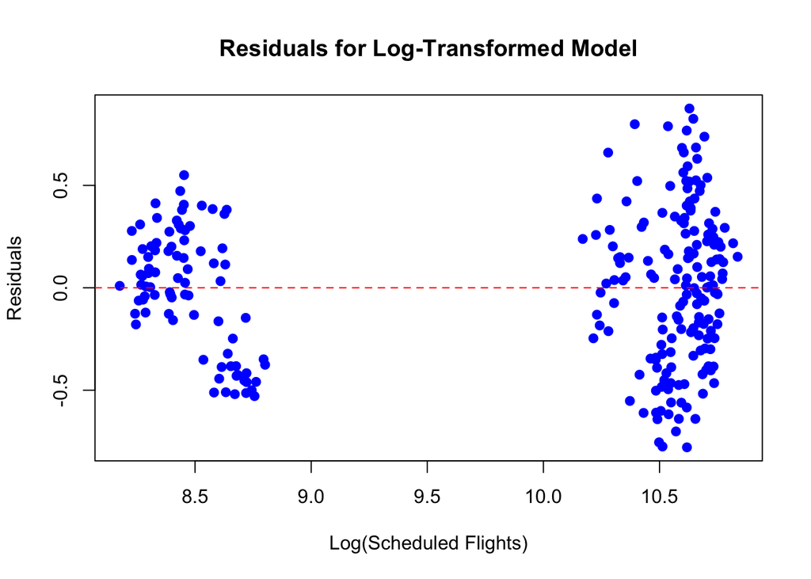

```r
# Residual Plot for Transformed Model
par(mfrow = c(1, 1)) # Reset plot area
log_res <- residuals(fit_log)
plot(log_res ~ log(baggagecomplaints$Scheduled),
     xlab = "Log(Scheduled Flights)", ylab = "Residuals",
     main = "Residuals for Log-Transformed Model",
     pch = 19, col = "blue")
abline(h = 0, col = "red", lty = 2)
```

### Multiple regression

```r
multi_model <- lm(baggagecomplaints$Baggage ~ baggagecomplaints$Scheduled + baggagecomplaints$Cancelled + baggagecomplaints$Enplaned, data = baggagecomplaints)
summary(multi_model)
```

```
##
## Call:
## lm(formula = baggagecomplaints$Baggage ~ baggagecomplaints$Scheduled +
##     baggagecomplaints$Cancelled + baggagecomplaints$Enplaned,
##     data = baggagecomplaints)
##
## Residuals:
##      Min       1Q   Median       3Q      Max
## -11286.5  -2303.6    165.1   1045.7  19903.0
##
## Coefficients:
##                               Estimate Std. Error t value Pr(>|t|)
## (Intercept)                 -1.429e+03  4.847e+02  -2.947  0.00351 **
## baggagecomplaints$Scheduled  8.639e-02  2.997e-02   2.882  0.00429 **
## baggagecomplaints$Cancelled  5.536e+00  5.501e-01  10.064  < 2e-16 ***
## baggagecomplaints$Enplaned   3.501e-03  2.060e-04  16.996  < 2e-16 ***
## ---
## Signif. codes:  0 '***' 0.001 '**' 0.01 '*' 0.05 '.' 0.1 ' ' 1
##
## Residual standard error: 3930 on 248 degrees of freedom
## Multiple R-squared:  0.8472, Adjusted R-squared:  0.8453
## F-statistic: 458.2 on 3 and 248 DF,  p-value: < 2.2e-16
```

```r
coefficients(multi_model)
```

```
##                 (Intercept) baggagecomplaints$Scheduled
##               -1.428574e+03                8.639476e-02
## baggagecomplaints$Cancelled  baggagecomplaints$Enplaned
##                5.536236e+00                3.501012e-03
```

```r
confint(multi_model, level = 0.95)
```

```
##                                     2.5 %        97.5 %
## (Intercept)                 -2.383228e+03 -4.739200e+02
## baggagecomplaints$Scheduled  2.736173e-02  1.454278e-01
## baggagecomplaints$Cancelled  4.452783e+00  6.619688e+00
## baggagecomplaints$Enplaned   3.095298e-03  3.906726e-03
```

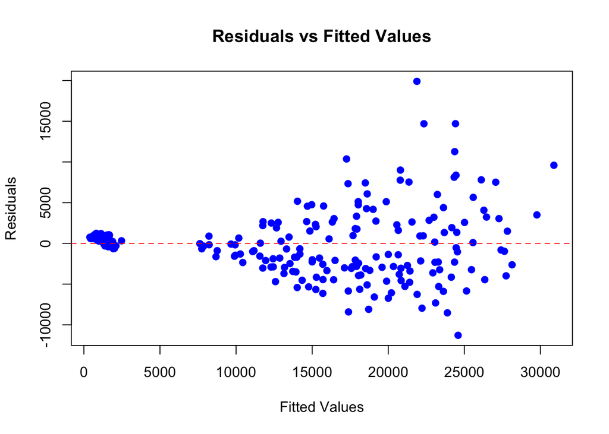

```r
# Residual Analysis
# Residuals vs Fitted
plot(multi_model$fitted.values, residuals(multi_model),
     xlab = "Fitted Values", ylab = "Residuals",
     main = "Residuals vs Fitted Values", pch = 19, col = "blue")
abline(h = 0, col = "red", lty = 2)
```

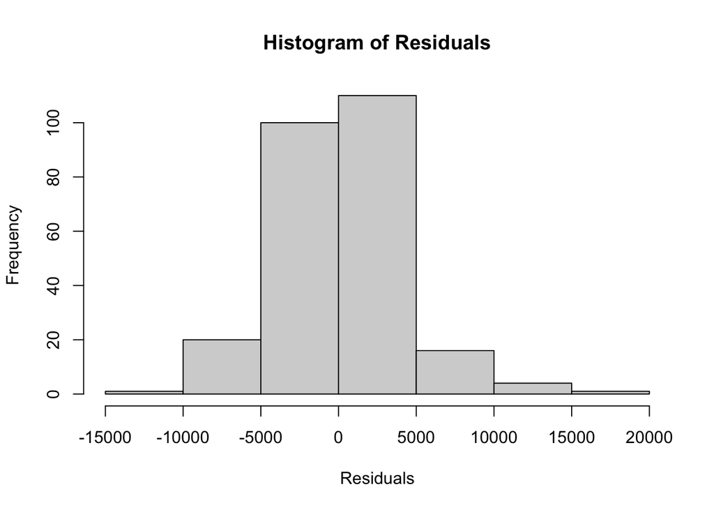

```r
# Histogram of Residuals
hist(residuals(multi_model), main = "Histogram of Residuals",
     xlab = "Residuals", border = "black")
```